# Manipulating containers

## Manipulating Data Containers

Storing data sets in data frames is very convenient, but with just the indexing notation, can make for cumbersome tasks.

Consider the following question (from UsingR): For the `normtemp` dataset perform a `t.test` for temperature by gender.

```r
normtemp <- UsingR::normtemp
```

## (No need to install `UsingR` – it is used just for this example.)

The data looks like:

```r
head(normtemp)
```

```
##   temperature gender hr
## 1        96.3      1 70
## 2        96.7      1 71
## 3        96.9      1 74
## 4        97.0      1 80
## 5        97.1      1 73
## 6        97.1      1 75
```

We see gender is coded. The docs say 1 for male 2 for female. Here we split the data to perform a "t test":

```r
males   <- normtemp[normtemp$gender == 1, "temperature"]
females <- normtemp[normtemp$gender == 2, "temperature"]
t.test(males, females)
```

```
##
##  Welch Two Sample t-test
##
## data:  males and females
## t = -2.2854, df = 127.51, p-value = 0.02394
## alternative hypothesis: true difference in means is not equal to 0
## 95 percent confidence interval:
##  -0.53964856 -0.03881298
## sample estimates:
## mean of x mean of y
##  98.10462  98.39385
```

Great, it appears there is a statististically significant difference in body temperature between male and females.

But why did this take take so much typing for something which seems simple: split the data and apply some function.

For R's modeling functions, like `t.test`, there is a syntax – the model formula – that is used to describe such tasks:

```r
t.test(temperature ~ gender, data=normtemp)
```

```
##
##  Welch Two Sample t-test
##
## data:  temperature by gender
## t = -2.2854, df = 127.51, p-value = 0.02394
## alternative hypothesis: true difference in means is not equal to 0
## 95 percent confidence interval:
##  -0.53964856 -0.03881298
## sample estimates:
## mean in group 1 mean in group 2
##        98.10462        98.39385
```

The expression/model formula

`temperature ~ gender`

means roughly "model temperature by the gender variable and apply the `t.test` to it. The code in `t.test` then splits the data by the `gender` variable, checks that this leaves 2 levels, and if so calls the `t.test` function in the more verbose manner.

The combination of R's model formula and its use of polymorphism (different methods can be called for different types of data usin g the same name) can bring easy-to-type, yet very expressive commands. Plotting is a good example. Here we see two different types of plots, as the two formulas represent different types of models:

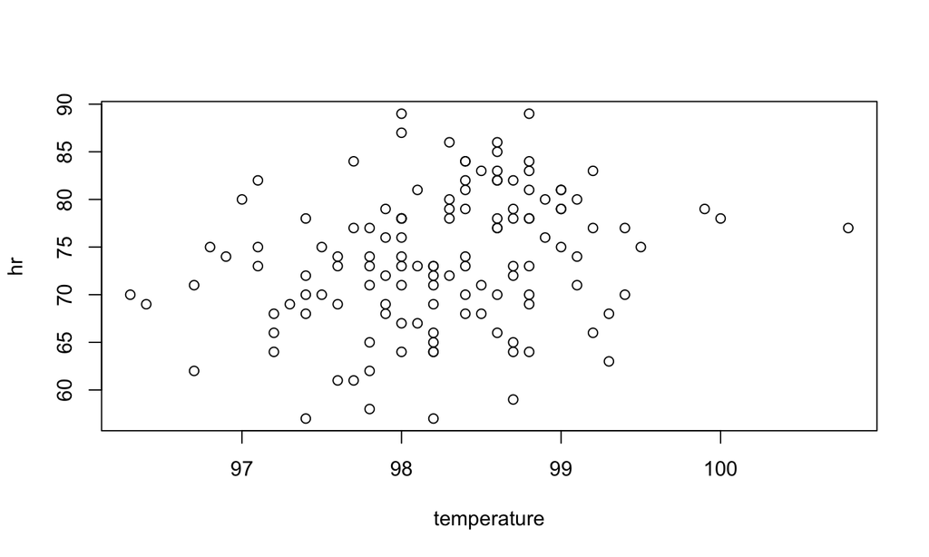

```r
plot(hr ~ temperature, data=normtemp)
```

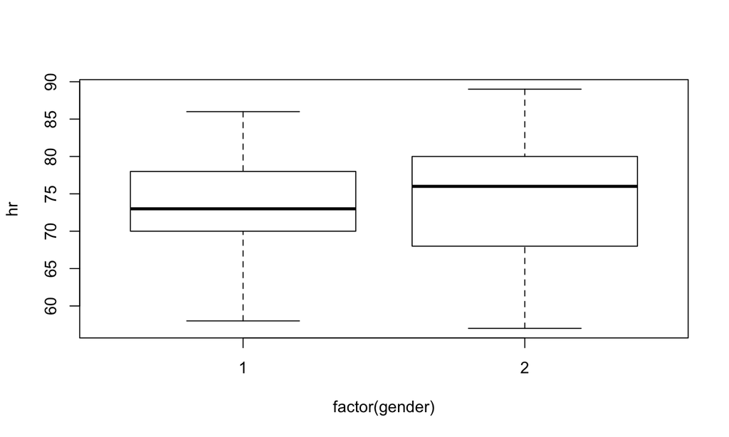

```r
plot(hr ~ factor(gender), data=normtemp)
```

That's good for this function. But what about a lower level task: finding the mean or standard deviation of a group? For these actions the model formula is not defined. As such, it is helpful to develop some basic data massaging tools related to data frames:

- subsetting (filtering) values
- reduction (selecting) variables to consider
- applying a function over a container
- grouping or splitting by values
- applying a function to groups of values

For these tasks we illustrate a few solutions, both with base `R` and with add-on packages.

## Exploring a data set

We will illustrate with two data sets, one modest, the other large

```r
library(nycflights13)   # install.packages("nycflights13") is needed at some point
library(MASS)           # Built in package
dim(flights)            # large
```

```
## [1] 336776     19
```

```r
dim(Cars93)             # modest
```

```
## [1] 93 27
```

What do we have?

In RStudio, a data frame can be shown in a (non-editable) table. Typically this involves just clicking on their entry in the "Environment" tab. But as these data sets come from built-in data sets, an extra step is needed to make them show up. The following looks silly, but it actually makes a copy in the current workspace:

```r
flights <- flights
Cars93 <- Cars93
```

Now double clicking will open up a window like

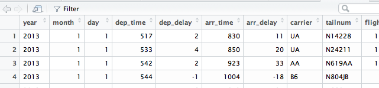

flights-view

There are times where we still want summaries without a graphical view. Here we have:

```r
dim(flights)    # dimensions, also nrow, length
```

```
## [1] 336776     19
```

```r
names(flights)   # also colnames
```

```
##  [1] "year"           "month"          "day"            "dep_time"
##  [5] "sched_dep_time" "dep_delay"      "arr_time"       "sched_arr_time"
##  [9] "arr_delay"      "carrier"        "flight"         "tailnum"
## [13] "origin"         "dest"           "air_time"       "distance"
## [17] "hour"           "minute"         "time_hour"
```

```r
summary(flights)
```

```
##       year          month             day           dep_time
##  Min.   :2013   Min.   : 1.000   Min.   : 1.00   Min.   :   1
##  1st Qu.:2013   1st Qu.: 4.000   1st Qu.: 8.00   1st Qu.: 907
##  Median :2013   Median : 7.000   Median :16.00   Median :1401
##  Mean   :2013   Mean   : 6.549   Mean   :15.71   Mean   :1349
##  3rd Qu.:2013   3rd Qu.:10.000   3rd Qu.:23.00   3rd Qu.:1744
##  Max.   :2013   Max.   :12.000   Max.   :31.00   Max.   :2400
##                                                  NA's   :8255
##  sched_dep_time   dep_delay          arr_time    sched_arr_time
##  Min.   : 106   Min.   : -43.00   Min.   :   1   Min.   :   1
##  1st Qu.: 906   1st Qu.:  -5.00   1st Qu.:1104   1st Qu.:1124
##  Median :1359   Median :  -2.00   Median :1535   Median :1556
##  Mean   :1344   Mean   :  12.64   Mean   :1502   Mean   :1536
##  3rd Qu.:1729   3rd Qu.:  11.00   3rd Qu.:1940   3rd Qu.:1945
##  Max.   :2359   Max.   :1301.00   Max.   :2400   Max.   :2359
##                 NA's   :8255      NA's   :8713
##    arr_delay          carrier              flight       tailnum
##  Min.   : -86.000   Length:336776      Min.   :   1   Length:336776
##  1st Qu.: -17.000   Class :character   1st Qu.: 553   Class :character
##  Median :  -5.000   Mode  :character   Median :1496   Mode  :character
##  Mean   :   6.895                      Mean   :1972
##  3rd Qu.:  14.000                      3rd Qu.:3465
##  Max.   :1272.000                      Max.   :8500
##  NA's   :9430
##     origin              dest              air_time        distance
##  Length:336776      Length:336776      Min.   : 20.0   Min.   :  17
##  Class :character   Class :character   1st Qu.: 82.0   1st Qu.: 502
##  Mode  :character   Mode  :character   Median :129.0   Median : 872
##                                        Mean   :150.7   Mean   :1040
##                                        3rd Qu.:192.0   3rd Qu.:1389
##                                        Max.   :695.0   Max.   :4983
##                                        NA's   :9430
##       hour           minute        time_hour
##  Min.   : 1.00   Min.   : 0.00   Min.   :2013-01-01 05:00:00
##  1st Qu.: 9.00   1st Qu.: 8.00   1st Qu.:2013-04-04 13:00:00
##  Median :13.00   Median :29.00   Median :2013-07-03 10:00:00
##  Mean   :13.18   Mean   :26.23   Mean   :2013-07-03 05:02:36
##  3rd Qu.:17.00   3rd Qu.:44.00   3rd Qu.:2013-10-01 07:00:00
##  Max.   :23.00   Max.   :59.00   Max.   :2013-12-31 23:00:00
##
```

## Subsetting, Filtering of vectors

What flights are JetBlue? We can see that the `carrier` variable is coded:

```r
table(flights$carrier)
```

```
##
##    9E    AA    AS    B6    DL    EV    F9    FL    HA    MQ    OO    UA
## 18460 32729   714 54635 48110 54173   685  3260   342 26397    32 58665
##    US    VX    WN    YV
## 20536  5162 12275   601
```

Looking at the referenced `airlines` data set, we see that `B6` is JetBlue. How to get just those flights? There are several ways:

```r
jb <- flights[flights$carrier == "B6",]   # base indexing
jb <- with(flights, flights[carrier=="B6", ]) # using with
jb <- subset(flights, carrier == "B6")    # new function
```

The shortest – by a hair – is the use of `subset`. This is a convenience function. Rather than describe that function, we mention a similar one from the `dplyr` package.

## Subsetting, Filtering data frames using `dplyr`

The `dplyr` package provides some higher-level interfaces to indexing. For this task – filtering our cases – we have the `filter` function.

First, we load the package:

```r
library(dplyr)   # ignore the many comments...
```

Here is `dplyr`'s alternative:

```r
jb <- filter(flights, carrier == "B6")
```

About the same as `subset`, but we can make our queries much more involved:

```r
jb <- filter(flights, carrier == "B6", origin == "JFK")
```

In the above, values get combined with `&`.

To use "ors", we can explicitly use `|`:

```r
jb <- filter(flights, carrier == "B6" | origin == "JFK")
```

(But not `&&` or `||` here, a common mistake)

Some other examples. What flights went over midnight?

Assuming the flights weren't over 24 hours, these would be flights whose arrival time is less than the depature time:

```r
red_eyes <- filter(flights, dep_time > arr_time)
nrow(red_eyes) / nrow(flights)
```

```
## [1] 0.03157291
```

What flights do not have a recorded air time?

```r
no_air <- filter(flights, is.na(flights$air_time))
dim(no_air)
```

```
## [1] 9430   19
```

Did any flights just turn around? (no)

```r
filter(flights, origin == dest)
```

```
## # A tibble: 0 x 19
## # ... with 19 variables: year <int>, month <int>, day <int>,
## #   dep_time <int>, sched_dep_time <int>, dep_delay <dbl>, arr_time <int>,
## #   sched_arr_time <int>, arr_delay <dbl>, carrier <chr>, flight <int>,
## #   tailnum <chr>, origin <chr>, dest <chr>, air_time <dbl>,
## #   distance <dbl>, hour <dbl>, minute <dbl>, time_hour <time>
```

## Reducing the number of variables

The `Cars93` data set has 27 variables. Suppose we only wanted to consider a selection of them. We can put in indices into the column position:

```r
a <- Cars93[, c(1, 2, 11, 12, 13,14)]
```

This can also use names for clarity:

```r
nms <- names(Cars93)[c(1, 2, 11, 12, 13,14)]  # or type ...
nms
```

```
## [1] "Manufacturer" "Model"        "Cylinders"    "EngineSize"
## [5] "Horsepower"   "RPM"
```

```r
a <- Cars93[, nms]
```

If you want all *but* a variable, negative indexing is useful.

```r
a <- Cars93[, -26]
dim(a)
```

```
## [1] 93 26
```

The `select` function of `dplyr` makes this slightly nicer if typing, as it uses non-standard evaluation of names:

```r
a <- dplyr::select(Cars93, Manufacturer, Model,
            Cylinders, EngineSize, Horsepower,    RPM)
```

It can also "fill in", the above covers two sequences:

```r
a <- select(Cars93, Manufacturer:Model, Cylinders:RPM)
head(a)
```

```
##   Manufacturer   Model Cylinders EngineSize Horsepower  RPM
## 1        Acura Integra         4        1.8        140 6300
## 2        Acura  Legend         6        3.2        200 5500
## 3         Audi      90         6        2.8        172 5500
## 4         Audi     100         6        2.8        172 5500
## 5          BMW    535i         4        3.5        208 5700
## 6        Buick Century         4        2.2        110 5200
```

At the **enormous** risk of confusing things, the built-in `Filter` function can also be helpful with this task. This function (note capital "F") reduces the elements of a vector or list to just those that satisfy some condition.

An example would be a means to remove variables which are not numeric:

```r
a <- Filter(is.numeric, Cars93)   # Filter(predicate, data)
dim(a)
```

```
## [1] 93 18
```

(Warning: lower case `filter` to filter rows, upper case to `Filter` columns, in a data frame.)

## Combining operations. We can combine these tasks:

```r
a <- flights[flights$carrier == "B6", c("distance")]
```

The "piping" function in `dplyr` (also `magrittr`) makes chaining distinct function calls pretty easy:

```r
a <- filter(flights, carrier == "B6") %>% select(distance)
```

Chaining (composing) versus monolithic calls.

The last command could also have been done in one function call using base R's `subset` function:

```
a <- subset(flights, carrier=="B6", select=distance)
```

Which is more natural?

Natural, of course, has a personal answer, but the programming style of most *newer* R packages is to try and create single-task functions that are *orthogonal* to each other, so functions combining two tasks into one call (`subset` basically does both `filter` and `select`) is a less common thing to see.

## Applying a function over a container

Earlier we mentioned that R vectorizes function calls so that this:

```
[x1 x2 ... xn] -> [f(x1) f(x2) ... f(xn)]
```

is simply `f(x)`. (When `f` is not a reduction.)

Can we do something similar for other containers? For example, lists?

```
[[ l1 l2 ... ln ]] -> [[ f(l1) f(l2) ... f(ln) ]]
```

The answer is "yes".

In general this is called a "map". R has the `Map` function, but more commonly you'll see one of `sapply`, `lapply` or `apply`

The different names are because there are various means to apply a function over the rows or columns of a matrix or data frame and over components of a list.

(The popular `plyr` package has many similar functions distinguished by the data types: `ddply`, `adply`, …)

## sapply

Say we have data in a data frame and we want to find the mean of each numeric column. We can do this in two steps:

- get just the numeric columns (`Filter`)
- apply the mean to each remaining one (`sapply`)

```r
x <- Filter(is.numeric, Cars93)     # Filter(function, data)
sapply(x, mean)                     # sapply(data, function)!!!
```

```
##          Min.Price              Price          Max.Price
##          17.125806          19.509677          21.898925
##           MPG.city        MPG.highway         EngineSize
##          22.365591          29.086022           2.667742
##         Horsepower                RPM       Rev.per.mile
##         143.827957        5280.645161        2332.204301
## Fuel.tank.capacity         Passengers             Length
##          16.664516           5.086022         183.204301
##          Wheelbase              Width        Turn.circle
##         103.946237          69.376344          38.956989
##     Rear.seat.room       Luggage.room             Weight
##                 NA                 NA        3072.903226
```

(How to get rid of the NA values?)

Earlier we saw that `summary` can be applied to data frames. This function also works for vectors. Calling it as follows is an alternative:

```r
sapply(flights, summary)
```

```
## $year
##    Min. 1st Qu.  Median    Mean 3rd Qu.    Max.
##    2013    2013    2013    2013    2013    2013
##
## $month
##    Min. 1st Qu.  Median    Mean 3rd Qu.    Max.
##   1.000   4.000   7.000   6.549  10.000  12.000
##
## $day
##    Min. 1st Qu.  Median    Mean 3rd Qu.    Max.
##    1.00    8.00   16.00   15.71   23.00   31.00
##
## $dep_time
##    Min. 1st Qu.  Median    Mean 3rd Qu.    Max.    NA's
##       1     907    1401    1349    1744    2400    8255
##
## $sched_dep_time
##    Min. 1st Qu.  Median    Mean 3rd Qu.    Max.
##     106     906    1359    1344    1729    2359
##
## $dep_delay
##    Min. 1st Qu.  Median    Mean 3rd Qu.    Max.    NA's
##  -43.00   -5.00   -2.00   12.64   11.00 1301.00    8255
##
## $arr_time
##    Min. 1st Qu.  Median    Mean 3rd Qu.    Max.    NA's
##       1    1104    1535    1502    1940    2400    8713
##
## $sched_arr_time
##    Min. 1st Qu.  Median    Mean 3rd Qu.    Max.
##       1    1124    1556    1536    1945    2359
##
## $arr_delay
##     Min.  1st Qu.   Median     Mean  3rd Qu.     Max.     NA's
##  -86.000  -17.000   -5.000    6.895   14.000 1272.000     9430
##
## $carrier
##    Length     Class      Mode
##    336776 character character
##
```

[output cut: 22 more lines]

```
##      17     502     872    1040    1389    4983
##
## $hour
##    Min. 1st Qu.  Median    Mean 3rd Qu.    Max.
##    1.00    9.00   13.00   13.18   17.00   23.00
##
## $minute
##    Min. 1st Qu.  Median    Mean 3rd Qu.    Max.
##    0.00    8.00   29.00   26.23   44.00   59.00
##
## $time_hour
##                  Min.               1st Qu.                Median
## "2013-01-01 05:00:00" "2013-04-04 13:00:00" "2013-07-03 10:00:00"
##                  Mean               3rd Qu.                  Max.
## "2013-07-03 05:02:36" "2013-10-01 07:00:00" "2013-12-31 23:00:00"
```

Note that one output was a *vector*, the other a *list*.

Part of the task of `sapply` (the "s" part) is to *simplify* the output – when possible.

Vectors are "simpler" than lists, so if possible the data is massaged into a vector.

The `lapply` function always returns a list, as does `Map`.

## Basics of functions

The functions `sapply`, `Map`, `lapply`, … are [higher-order](https://en.wikipedia.org/wiki/Higher-order_function) functions. For one of the arguments, we pass in a function object by name (or anonymously). Often these functions are already defined for us (e.g., `is.numeric`), but there are times where we would want to define our own. For example, one way to remove NA values before computing the mean is to set the argument `na.rm=TRUE`. It is false by default. We could do this:

```r
our_mean <- function(x) mean(x, na.rm=TRUE)
```

Then we can use:

```r
sapply(Filter(is.numeric, Cars93),   our_mean)
```

```
##          Min.Price              Price          Max.Price
##          17.125806          19.509677          21.898925
##           MPG.city        MPG.highway         EngineSize
##          22.365591          29.086022           2.667742
##         Horsepower                RPM       Rev.per.mile
##         143.827957        5280.645161        2332.204301
## Fuel.tank.capacity         Passengers             Length
##          16.664516           5.086022         183.204301
##          Wheelbase              Width        Turn.circle
##         103.946237          69.376344          38.956989
##     Rear.seat.room       Luggage.room             Weight
##          27.829670          13.890244        3072.903226
```

This task of setting an argument to a function is common enough that `sapply` permits passing these as additional arguments, so more idiomatically we would have:

```
sapply(Filter(is.numeric, Cars93),  mean, na.rm=TRUE)
```

But being able to define simple functions is very useful.

## Functions: basic

Without diving in too deeply now, the basic template for a *simple* function is just:

```
fn_name <- function(x) {
   ... do something with x ....
   ... last value evaluated is the value returned ...
}
```

In our previous example, we only have one command, so the braces were optional.

## anonymous functions

If you want to reduce typing, we can even define functions "anonymously":

```
sapply(Filter(is.numeric, Cars93), function(x) mean(x, na.rm=TRUE))
```

That double composition gets to be too much to read, but is not so hard to type when needed.

## splitting or grouping

We return to the motivating example: splitting and then applying some function.

First, splitting. Base R has the command `split` that can be used to create a list of groups defined by some factor. For example, the `Cars93` data set has the `Origin` factor:

```r
by_origin <- split(Cars93, Cars93$Origin)
```

The `by_origin` variable is a list with two components: one for `USA` and one `non-USA` – the different levels of `Origin`.

```r
names(by_origin)
```

```
## [1] "USA"     "non-USA"
```

If we wanted we can apply a function to each component.

For example, here is *one* way to get the number of cases in each:

```r
sapply(by_origin, nrow)
```

```
##     USA non-USA
##      48      45
```

You could argue `table(Cars93$Origin)` is more direct for this taks, but using `sapply` is much more versatile.

To get the average mileage for each requires a function which takes a data frame and returns the average of one of its variables. For that there is nothing built-in, so we roll our own:

```r
sapply(by_origin, function(d) mean(d$MPG.highway))
```

```
##      USA  non-USA
## 28.14583 30.08889
```

(It would be nicer to just say `summarize(by_origin, mean(MPG.highway)` but that is coming.)

We can see the total distance each airplane (unique tail numbers) flew with the following chained set of commands:

```r
out <- split(flights, flights$tailnum) %>%
  sapply(function(d) sum(d$distance, na.rm=TRUE)) %>%
    sort(decreasing=TRUE) %>%
      head(n=5)
out
```

```
## N328AA N338AA N327AA N335AA N323AA
## 939101 931183 915665 909696 844529
```

What do we know about the airlines that worked these planes so hard?

```r
with(flights, flights[tailnum == names(out)[-1], "carrier"])
```

```
## # A tibble: 2,890 x 1
##    carrier
##      <chr>
## 1     <NA>
## 2     <NA>
## 3     <NA>
## 4     <NA>
## 5       AA
## 6       AA
## 7     <NA>
## 8     <NA>
## 9       AA
## 10    <NA>
## # ... with 2,880 more rows
```

They were all American. (Why a data frame print out?)

Hmm, interesting. Can we get the distance traveled by carrier?

```r
out <- split(flights, flights$carrier) %>%
  sapply(function(d) sum(d$distance, na.rm=TRUE)) %>%
     sort(decreasing=TRUE) %>%
          head(n=5)
out
```

```
##       UA       DL       B6       AA       EV
## 89705524 59507317 58384137 43864584 30498951
```

And these are

```r
filter(airlines, carrier %in% names(out))
```

```
## # A tibble: 5 x 2
##   carrier                     name
##     <chr>                    <chr>
## 1      AA   American Airlines Inc.
## 2      B6          JetBlue Airways
## 3      DL     Delta Air Lines Inc.
## 4      EV ExpressJet Airlines Inc.
## 5      UA    United Air Lines Inc.
```

## group_by

The `dplyr` package provides `group_by` which makes some of these tasks a bit more straightforward. The `group_by` function does the splitting:

```r
group_by(flights, carrier)   # no need to qualify `carrier`
```

```
## Source: local data frame [336,776 x 19]
## Groups: carrier [16]
##
##     year month   day dep_time sched_dep_time dep_delay arr_time
##    <int> <int> <int>    <int>          <int>     <dbl>    <int>
## 1   2013     1     1      517            515         2      830
## 2   2013     1     1      533            529         4      850
## 3   2013     1     1      542            540         2      923
## 4   2013     1     1      544            545        -1     1004
## 5   2013     1     1      554            600        -6      812
## 6   2013     1     1      554            558        -4      740
## 7   2013     1     1      555            600        -5      913
## 8   2013     1     1      557            600        -3      709
## 9   2013     1     1      557            600        -3      838
## 10  2013     1     1      558            600        -2      753
## # ... with 336,766 more rows, and 12 more variables: sched_arr_time <int>,
## #   arr_delay <dbl>, carrier <chr>, flight <int>, tailnum <chr>,
## #   origin <chr>, dest <chr>, air_time <dbl>, distance <dbl>, hour <dbl>,
## #   minute <dbl>, time_hour <time>
```

We had this expression: `

```
by_origin <- split(Cars93, Cars93$Origin)
sapply(by_origin, function(d) mean(d$MPG.highway))
```

Now, we can get there more easily with the `group_by` and `summarize` functions:

```r
by_origin <- group_by(Cars93, Origin)
summarize(by_origin, mean(MPG.highway))
```

```
## # A tibble: 2 x 2
##    Origin mean(MPG.highway)
##    <fctr>             <dbl>
## 1     USA          28.14583
## 2 non-USA          30.08889
```

As well, we can chain different tasks:

```r
out = group_by(flights, carrier) %>%   # no need to qualify `carrier`
  summarize(dist = sum(distance)) %>%  # summarize distances
    arrange(desc(dist)) %>%            # arrange sorts
      head(n=5)                        # first 5 only
out
```

```
## # A tibble: 5 x 2
##   carrier     dist
##     <chr>    <dbl>
## 1      UA 89705524
## 2      DL 59507317
## 3      B6 58384137
## 4      AA 43864584
## 5      EV 30498951
```

Not sure this is more clear or less. We see, again, the use of `summarize`, but also `arrange` and `head`.

The `arrange` function plays the role of sort, but `arrange` is working on a data frame and `sort` on a vector.

The `summarize` function makes it easy to apply a reduction to groups. For example, to find the mean and standard deviation of distance for each carrier would be done with:

```r
group_by(flights, carrier) %>%
  summarize(mean=mean(distance), sd=sd(distance)) %>%
     arrange(desc(mean)) %>% head
```

```
## # A tibble: 6 x 3
##   carrier     mean        sd
##     <chr>    <dbl>     <dbl>
## 1      HA 4983.000   0.00000
## 2      VX 2499.482  88.04889
## 3      AS 2402.000   0.00000
## 4      F9 1620.000   0.00000
## 5      UA 1529.115 798.80468
## 6      AA 1340.236 637.73615
```

(What is a 0 sd?)